# R Notebook

Installing the packages:

```r
install.packages("outliers")
install.packages("scatterplot3d")
install.packages("dplyr")
install.packages("ggplot2")
install.packages("colorspace")
```

# Reading libraries

```r
library(ggplot2)
library(outliers)
library(scatterplot3d)
library(dplyr)
library(readr)
```

## load the data

```r
dataset <- read_csv("salary.csv")
```

1- General information about the Dataset

#Sample of raw dataset and summary

```r
head(dataset)
```

| age | workclass | fnlwgt | education | education-num | marital-status | occupation | relationship | race | sex | capital-gain | capital-loss | hours-per-week | native-country | salary |
| --- | --- | --- | --- | --- | --- | --- | --- | --- | --- | --- | --- | --- | --- | --- |
| 39 | State-gov | 77516 | Bachelors | 13 | Never-married | Adm-clerical | Not-in-family | White | Male | 2174 | 0 | 40 | United-States | <=50K |
| 50 | Self-emp-not-inc | 83311 | Bachelors | 13 | Married-civ-spouse | Exec-managerial | Husband | White | Male | 0 | 0 | 13 | United-States | <=50K |
| 38 | Private | 215646 | HS-grad | 9 | Divorced | Handlers-cleaners | Not-in-family | White | Male | 0 | 0 | 40 | United-States | <=50K |
| 53 | Private | 234721 | 11th | 7 | Married-civ-spouse | Handlers-cleaners | Husband | Black | Male | 0 | 0 | 40 | United-States | <=50K |
| 28 | Private | 338409 | Bachelors | 13 | Married-civ-spouse | Prof-specialty | Wife | Black | Female | 0 | 0 | 40 | Cuba | <=50K |
| 37 | Private | 284582 | Masters | 14 | Married-civ-spouse | Exec-managerial | Wife | White | Female | 0 | 0 | 40 | United-States | <=50K |

```r
summary(dataset)
```

```
      age         workclass             fnlwgt         education
 Min.   :17.00   Length:32561       Min.   :  12285   Length:32561
 1st Qu.:28.00   Class :character   1st Qu.: 117827   Class :character
 Median :37.00   Mode  :character   Median : 178356   Mode  :character
 Mean   :38.58                      Mean   : 189778
 3rd Qu.:48.00                      3rd Qu.: 237051
 Max.   :90.00                      Max.   :1484705
 education-num   marital-status      occupation        relationship
 Min.   : 1.00   Length:32561       Length:32561       Length:32561
 1st Qu.: 9.00   Class :character   Class :character   Class :character
 Median :10.00   Mode  :character   Mode  :character   Mode  :character
 Mean   :10.08
 3rd Qu.:12.00
 Max.   :16.00
     race               sex             capital-gain    capital-loss
 Length:32561       Length:32561       Min.   :    0   Min.   :   0.0
 Class :character   Class :character   1st Qu.:    0   1st Qu.:   0.0
 Mode  :character   Mode  :character   Median :    0   Median :   0.0
                                       Mean   : 1078   Mean   :  87.3
                                       3rd Qu.:    0   3rd Qu.:   0.0
                                       Max.   :99999   Max.   :4356.0
 hours-per-week  native-country        salary
 Min.   : 1.00   Length:32561       Length:32561
 1st Qu.:40.00   Class :character   Class :character
 Median :40.00   Mode  :character   Mode  :character
 Mean   :40.44
 3rd Qu.:45.00
 Max.   :99.00
```

First and foremost, we will remove a few of our columns. We will remove education, capital.gain, and capital.loss. Education to avoid redundancy, as we believe education.num is adequate on its own. We will remove capital.loss and capital.gain due to low variance, with overwhelming majority of rows being zero.

```r
dataset<- dataset[-c(4, 11,12)]
print(dataset)
```

| age | workclass | fnlwgt | education-num | marital-status | occupation | relationship | race | sex | hours-per-week | native-country | salary |
| --- | --- | --- | --- | --- | --- | --- | --- | --- | --- | --- | --- |
| 39 | State-gov | 77516 | 13 | Never-married | Adm-clerical | Not-in-family | White | Male | 40 | United-States | <=50K |
| 50 | Self-emp-not-inc | 83311 | 13 | Married-civ-spouse | Exec-managerial | Husband | White | Male | 13 | United-States | <=50K |
| 38 | Private | 215646 | 9 | Divorced | Handlers-cleaners | Not-in-family | White | Male | 40 | United-States | <=50K |
| 53 | Private | 234721 | 7 | Married-civ-spouse | Handlers-cleaners | Husband | Black | Male | 40 | United-States | <=50K |
| 28 | Private | 338409 | 13 | Married-civ-spouse | Prof-specialty | Wife | Black | Female | 40 | Cuba | <=50K |
| 37 | Private | 284582 | 14 | Married-civ-spouse | Exec-managerial | Wife | White | Female | 40 | United-States | <=50K |
| 49 | Private | 160187 | 5 | Married-spouse-absent | Other-service | Not-in-family | Black | Female | 16 | Jamaica | <=50K |
| 52 | Self-emp-not-inc | 209642 | 9 | Married-civ-spouse | Exec-managerial | Husband | White | Male | 45 | United-States | >50K |
| 31 | Private | 45781 | 14 | Never-married | Prof-specialty | Not-in-family | White | Female | 50 | United-States | >50K |
| 42 | Private | 159449 | 13 | Married-civ-spouse | Exec-managerial | Husband | White | Male | 40 | United-States | >50K |

[output cut: 990 more lines]

#Encoding the data: The reason we performed encoding on our dataset is because it not only preserves the integrity of our data, but also because machine learning algorithms work with numerical values.

```r
dataset$workclass <-  as.integer(factor(dataset$workclass))
dataset$`marital-status` <-  as.integer(factor(dataset$`marital-status`))
dataset$occupation <-  as.integer(factor(dataset$occupation))
dataset$relationship <-  as.integer(factor(dataset$workclass))
dataset$race <-  as.integer(factor(dataset$race))
dataset$sex <-  as.integer(factor(dataset$sex))
dataset$`native-country` <-  as.integer(factor(dataset$`native-country`))
print(dataset)
```

| age | workclass | fnlwgt | education-num | marital-status | occupation | relationship | race | sex | hours-per-week | native-country | salary |
| --- | --- | --- | --- | --- | --- | --- | --- | --- | --- | --- | --- |
| 39 | 8 | 77516 | 13 | 5 | 2 | 8 | 5 | 2 | 40 | 40 | <=50K |
| 50 | 7 | 83311 | 13 | 3 | 5 | 7 | 5 | 2 | 13 | 40 | <=50K |
| 38 | 5 | 215646 | 9 | 1 | 7 | 5 | 5 | 2 | 40 | 40 | <=50K |
| 53 | 5 | 234721 | 7 | 3 | 7 | 5 | 3 | 2 | 40 | 40 | <=50K |
| 28 | 5 | 338409 | 13 | 3 | 11 | 5 | 3 | 1 | 40 | 6 | <=50K |
| 37 | 5 | 284582 | 14 | 3 | 5 | 5 | 5 | 1 | 40 | 40 | <=50K |
| 49 | 5 | 160187 | 5 | 4 | 9 | 5 | 3 | 1 | 16 | 24 | <=50K |
| 52 | 7 | 209642 | 9 | 3 | 5 | 7 | 5 | 2 | 45 | 40 | >50K |
| 31 | 5 | 45781 | 14 | 5 | 11 | 5 | 5 | 1 | 50 | 40 | >50K |
| 42 | 5 | 159449 | 13 | 3 | 5 | 5 | 5 | 2 | 40 | 40 | >50K |

[output cut: 990 more lines]

2- Data Preprocessing

*Removing missing values:

```r
sum(is.na(dataset))
```

```
[1] 0
```

```r
dataset <- dataset[!apply(dataset == "?", 1, any), ]
dataset <- na.omit(dataset)
print(dataset)
```

| age | workclass | fnlwgt | education-num | marital-status | occupation | relationship | race | sex | hours-per-week | native-country | salary |
| --- | --- | --- | --- | --- | --- | --- | --- | --- | --- | --- | --- |
| 39 | 8 | 77516 | 13 | 5 | 2 | 8 | 5 | 2 | 40 | 40 | <=50K |
| 50 | 7 | 83311 | 13 | 3 | 5 | 7 | 5 | 2 | 13 | 40 | <=50K |
| 38 | 5 | 215646 | 9 | 1 | 7 | 5 | 5 | 2 | 40 | 40 | <=50K |
| 53 | 5 | 234721 | 7 | 3 | 7 | 5 | 3 | 2 | 40 | 40 | <=50K |
| 28 | 5 | 338409 | 13 | 3 | 11 | 5 | 3 | 1 | 40 | 6 | <=50K |
| 37 | 5 | 284582 | 14 | 3 | 5 | 5 | 5 | 1 | 40 | 40 | <=50K |
| 49 | 5 | 160187 | 5 | 4 | 9 | 5 | 3 | 1 | 16 | 24 | <=50K |
| 52 | 7 | 209642 | 9 | 3 | 5 | 7 | 5 | 2 | 45 | 40 | >50K |
| 31 | 5 | 45781 | 14 | 5 | 11 | 5 | 5 | 1 | 50 | 40 | >50K |
| 42 | 5 | 159449 | 13 | 3 | 5 | 5 | 5 | 2 | 40 | 40 | >50K |

[output cut: 990 more lines]

```r
OutAge = outlier(dataset$age, logical =TRUE)
sum(OutAge)
```

```
[1] 43
```

```r
Find_outlier = which(OutAge ==TRUE, arr.ind = TRUE)

####
Outfnlwgt = outlier(dataset$fnlwgt, logical =TRUE)
sum(Outfnlwgt)
```

```
[1] 1
```

```r
Find_outlier = which(Outfnlwgt ==TRUE, arr.ind = TRUE)

###
Outeducation = outlier(dataset$`education-num`, logical =TRUE)
sum(Outeducation)
```

```
[1] 51
```

```r
Find_outlier = which(Outeducation ==TRUE, arr.ind = TRUE)

##

Outhours = outlier(dataset$`hours-per-week`, logical =TRUE)
sum(Outhours)
```

```
[1] 85
```

```r
Find_outlier = which(Outhours ==TRUE, arr.ind = TRUE)



#Remove outlier
dataset= dataset[-Find_outlier,]
```

Printing the dataset after cleaning the data

```r
print(dataset)
```

| age | workclass | fnlwgt | education-num | marital-status | occupation | relationship | race | sex | hours-per-week | native-country | salary |
| --- | --- | --- | --- | --- | --- | --- | --- | --- | --- | --- | --- |
| 39 | 8 | 77516 | 13 | 5 | 2 | 8 | 5 | 2 | 40 | 40 | <=50K |
| 50 | 7 | 83311 | 13 | 3 | 5 | 7 | 5 | 2 | 13 | 40 | <=50K |
| 38 | 5 | 215646 | 9 | 1 | 7 | 5 | 5 | 2 | 40 | 40 | <=50K |
| 53 | 5 | 234721 | 7 | 3 | 7 | 5 | 3 | 2 | 40 | 40 | <=50K |
| 28 | 5 | 338409 | 13 | 3 | 11 | 5 | 3 | 1 | 40 | 6 | <=50K |
| 37 | 5 | 284582 | 14 | 3 | 5 | 5 | 5 | 1 | 40 | 40 | <=50K |
| 49 | 5 | 160187 | 5 | 4 | 9 | 5 | 3 | 1 | 16 | 24 | <=50K |
| 52 | 7 | 209642 | 9 | 3 | 5 | 7 | 5 | 2 | 45 | 40 | >50K |
| 31 | 5 | 45781 | 14 | 5 | 11 | 5 | 5 | 1 | 50 | 40 | >50K |
| 42 | 5 | 159449 | 13 | 3 | 5 | 5 | 5 | 2 | 40 | 40 | >50K |

[output cut: 990 more lines]

Create a new column called num_salary to transform the binary attribute into numerical to use it better as it it the class label

```r
dataset$num_salary <- ifelse(dataset$salary == ">50K", 1, 0)
```

2.4- Data transformation

Normalization Normalization is applied as part of data preparation for machine learning. Its purpose is to change the values of numeric columns in the dataset to use a common scale, without distorting differences in the ranges of values or losing information.

Normalize attributes: age, fnlwgt

```r
dataWithoutNormalization <- dataset

#Define function normalize().
normalize <- function(x) {return ((x - min(x)) / (max(x) - min(x)))}
#Define function Z_normalize().
Z_normalize <- function(x) {return ((x - mean(x)) / sd(x))}

#Call normalize funcrtion
dataset$age<-normalize(dataWithoutNormalization$age)


#Call Z_normalize funcrtion
dataset$age<-Z_normalize(dataWithoutNormalization$age)


######################################

#Call normalize funcrtion
dataset$fnlwgt<-normalize(dataWithoutNormalization$fnlwgt)


#Call Z_normalize funcrtion
dataset$fnlwgt<-Z_normalize(dataWithoutNormalization$fnlwgt)

print(dataset) # data after normalization
```

| age | workclass | fnlwgt | education-num | marital-status | occupation | relationship | race | sex | hours-per-week | native-country | salary | num_salary |
| --- | --- | --- | --- | --- | --- | --- | --- | --- | --- | --- | --- | --- |
| 0.03162036 | 8 | -1.0643248559 | 13 | 5 | 2 | 8 | 5 | 2 | 40 | 40 | <=50K | 0 |
| 0.83812705 | 7 | -1.0094204954 | 13 | 3 | 5 | 7 | 5 | 2 | 13 | 40 | <=50K | 0 |
| -0.04169842 | 5 | 0.2443790801 | 9 | 1 | 7 | 5 | 5 | 2 | 40 | 40 | <=50K | 0 |
| 1.05808342 | 5 | 0.4251039594 | 7 | 3 | 7 | 5 | 3 | 2 | 40 | 40 | <=50K | 0 |
| -0.77488632 | 5 | 1.4074893479 | 13 | 3 | 11 | 5 | 3 | 1 | 40 | 6 | <=50K | 0 |
| -0.11501721 | 5 | 0.8975088458 | 14 | 3 | 5 | 5 | 5 | 1 | 40 | 40 | <=50K | 0 |
| 0.76480826 | 5 | -0.2810637027 | 5 | 4 | 9 | 5 | 3 | 1 | 16 | 24 | <=50K | 0 |
| 0.98476463 | 7 | 0.1874945624 | 9 | 3 | 5 | 7 | 5 | 2 | 45 | 40 | >50K | 1 |
| -0.55492995 | 5 | -1.3649961033 | 14 | 5 | 11 | 5 | 5 | 1 | 50 | 40 | >50K | 1 |
| 0.25157673 | 5 | -0.2880558369 | 13 | 3 | 5 | 5 | 5 | 2 | 40 | 40 | >50K | 1 |

[output cut: 990 more lines]

```r
NA
NA
NA
```

3- Data Summary and Visualixation

3.1- Data summary after preprocessing:

```r
# number of rows
nrow(dataset)
```

```
[1] 32476
```

```r
# number of columns
ncol(dataset)
```

```
[1] 13
```

```r
# Dimensionalitly
 dim(dataset)
```

```
[1] 32476    13
```

*Show the column Names of Clean (Preprocessed) Dataset

```r
names(dataset)
```

```
 [1] "age"            "workclass"      "fnlwgt"         "education-num"
 [5] "marital-status" "occupation"     "relationship"   "race"
 [9] "sex"            "hours-per-week" "native-country" "salary"
[13] "num_salary"
```

*Provide a summary of the Data

```r
summary(dataset$age)
```

```
   Min. 1st Qu.  Median    Mean 3rd Qu.    Max.
-1.5814 -0.7749 -0.1150  0.0000  0.6915  3.7709
```

```r
summary(dataset$`hours-per-week`)
```

```
   Min. 1st Qu.  Median    Mean 3rd Qu.    Max.
   1.00   40.00   40.00   40.28   45.00   98.00
```

```r
summary(dataset$occupation)
```

```
   Min. 1st Qu.  Median    Mean 3rd Qu.    Max.
   1.00    4.00    8.00    7.57   11.00   15.00
```

```r
summary(dataset$sex)
```

```
   Min. 1st Qu.  Median    Mean 3rd Qu.    Max.
  1.000   1.000   2.000   1.669   2.000   2.000
```

```r
summary(dataset$salary)
```

```
   Length     Class      Mode
    32476 character character
```

*Show the variance of age and hours.per.week

```r
var(dataset$age)
```

```
[1] 1
```

```r
var(dataset$`hours-per-week`)
```

```
[1] 143.858
```

Create a density plot for the age variable

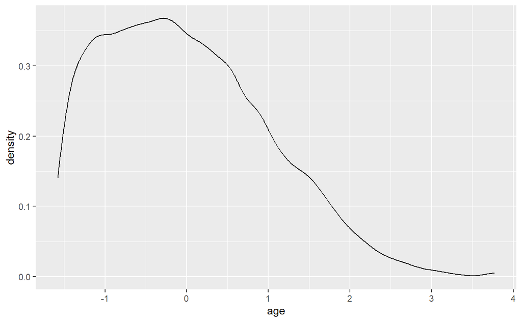

```r
ggplot(data = dataset, aes(x = age)) +
  geom_density()
```

# Plotting:

*Histograms ### Histogram of the age variable

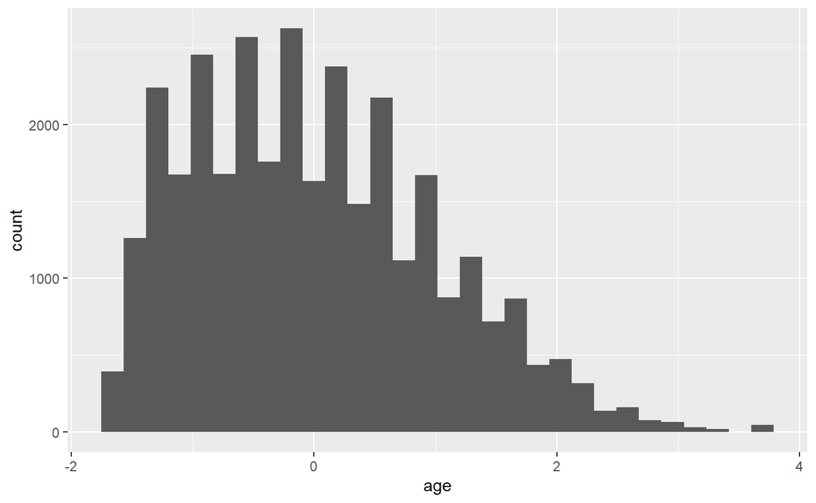

```r
ggplot(dataset, aes(x = age)) +
  geom_histogram()
```

### Histogram of the num_salary variable where the 1 represents salary >=50k and 0 represents salary <50k

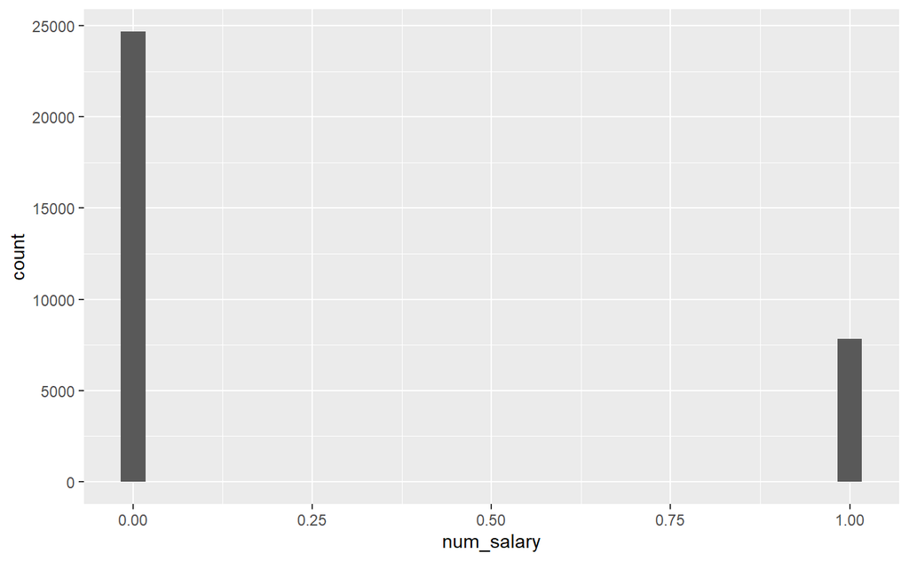

```r
ggplot(dataset, aes(x = num_salary)) +
  geom_histogram()
```

### Histogram of the hours-per-week variable

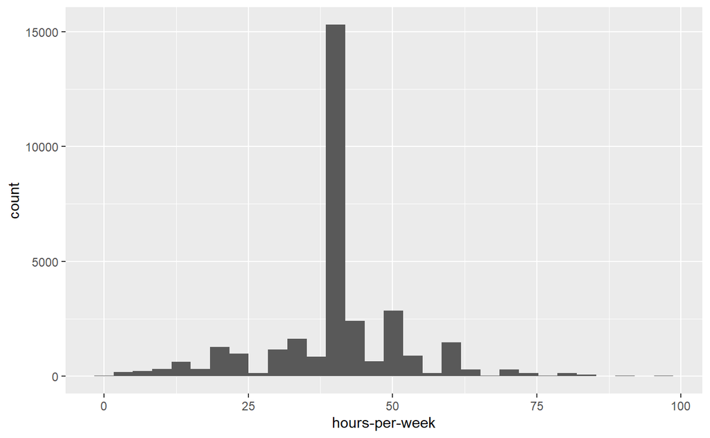

```r
ggplot(dataset, aes(x =`hours-per-week`)) +
  geom_histogram()
```

### Histogram of the fnlwgt variable

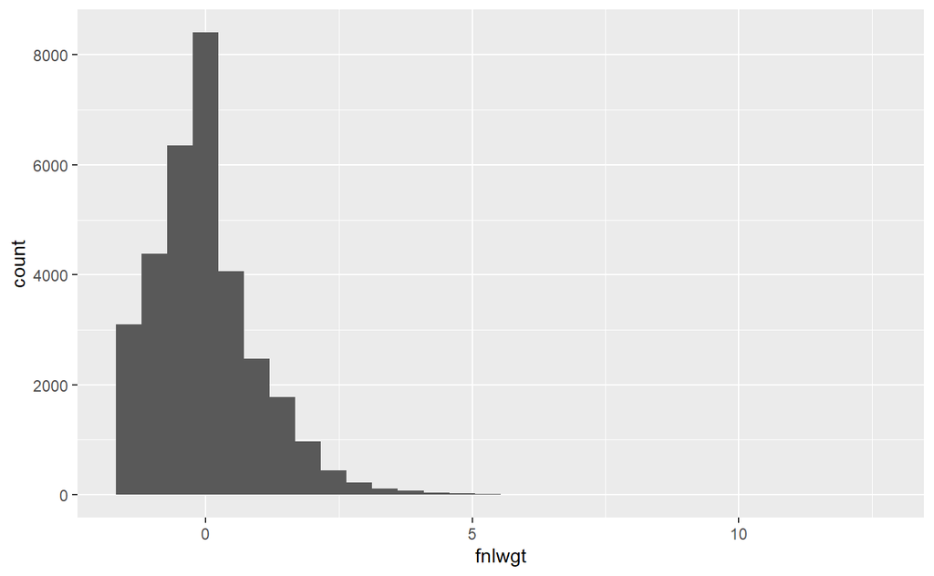

```r
ggplot(dataset, aes(x = fnlwgt)) +
  geom_histogram()
```

*Barplots ### Bar plot of the workclass variable

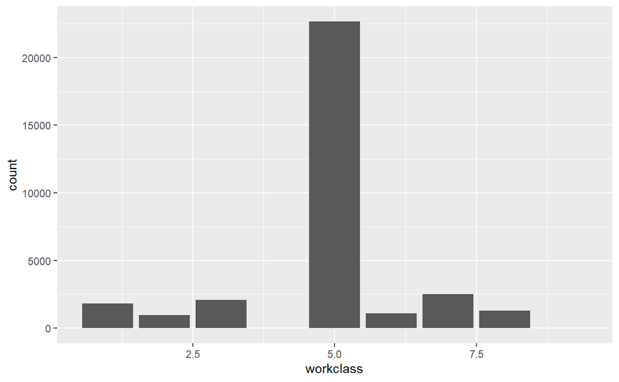

```r
ggplot(dataset, aes(x = workclass)) + geom_bar()
```

### Bar plot of the occupation variable

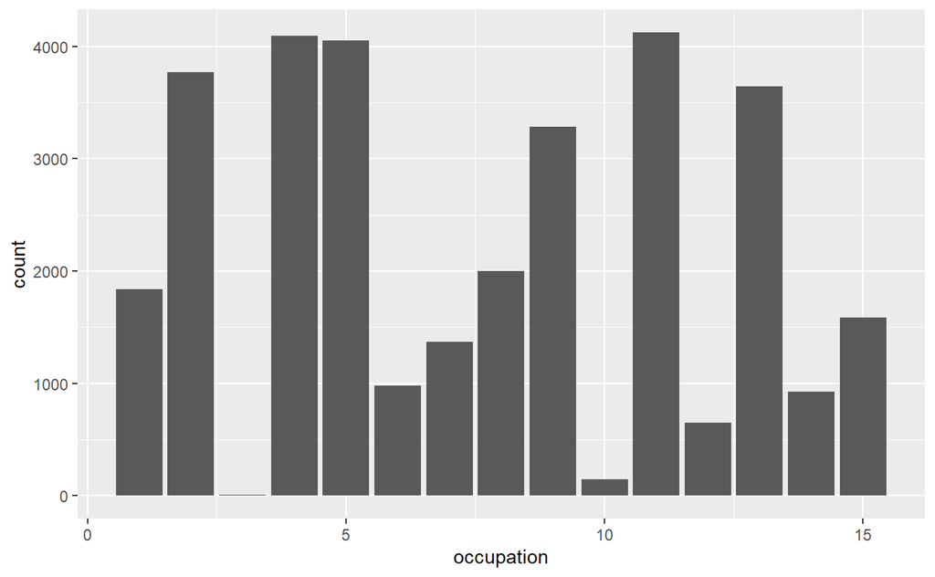

```r
ggplot(dataset, aes(x = occupation)) + geom_bar()
```

### Bar plot of the relationship variable

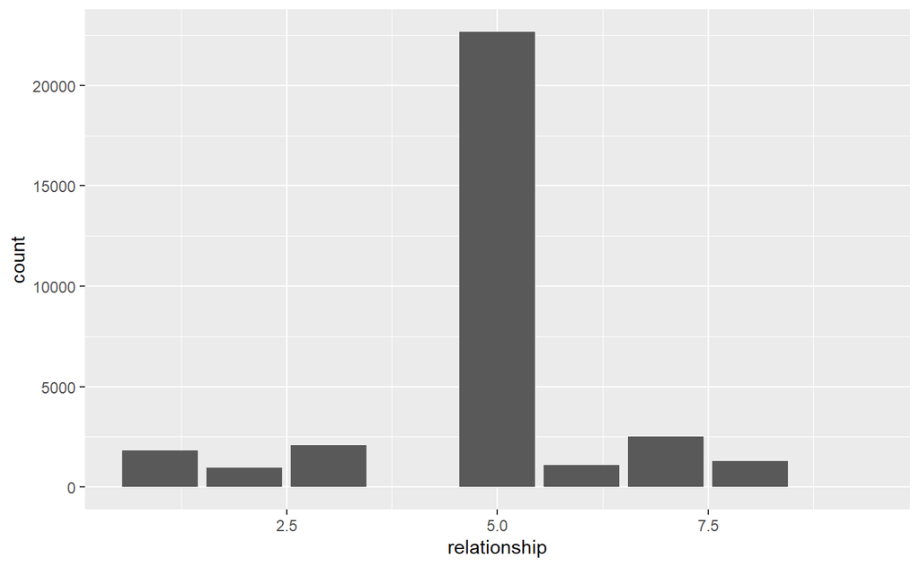

```r
ggplot(dataset, aes(x = relationship)) + geom_bar()
```

### Bar plot of the sex variable

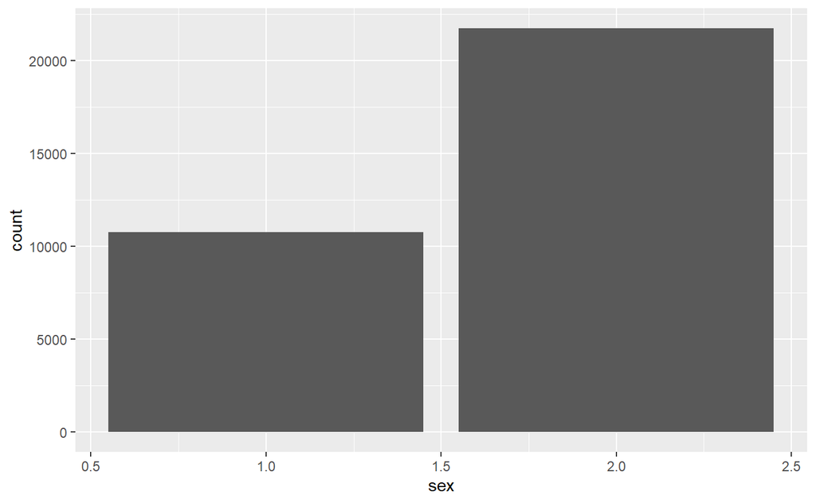

```r
ggplot(dataset, aes(x = sex)) +geom_bar()
```

### Bar plot of the salary variable

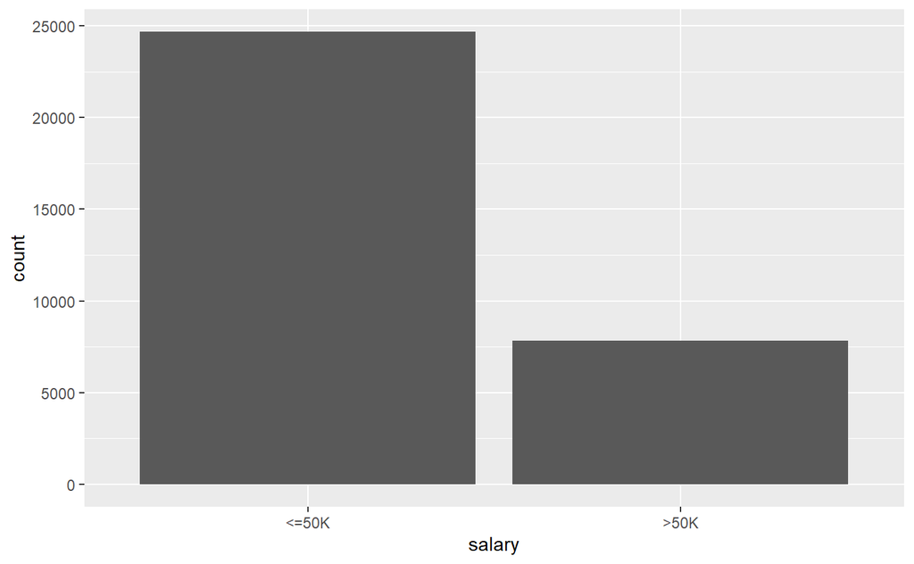

```r
ggplot(dataset, aes(x = salary)) + geom_bar()
```

*Boxplots

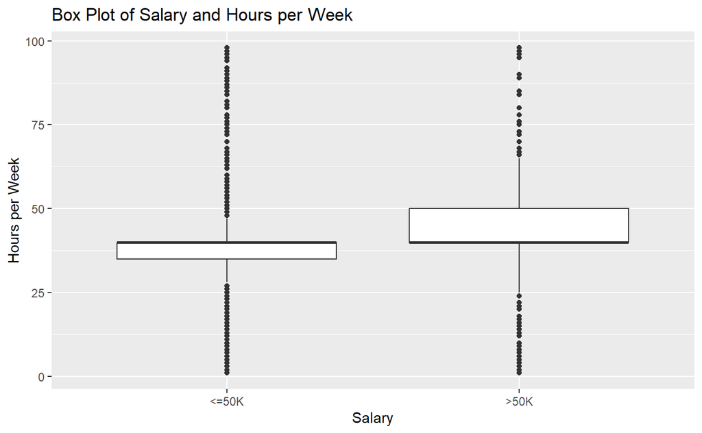

```r
ggplot(dataset, aes(x = salary, y = `hours-per-week`)) +
  geom_boxplot() +
  labs(title = "Box Plot of Salary and Hours per Week", x = "Salary", y = "Hours per Week")
```

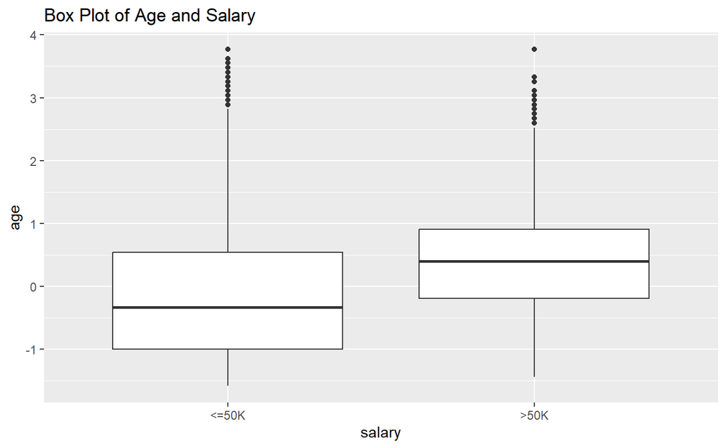

```r
ggplot(dataset, aes(x = salary, y = age)) +
  geom_boxplot() +
  labs(title = "Box Plot of Age and Salary", x = "salary", y = "age")
```

*Scatterplot

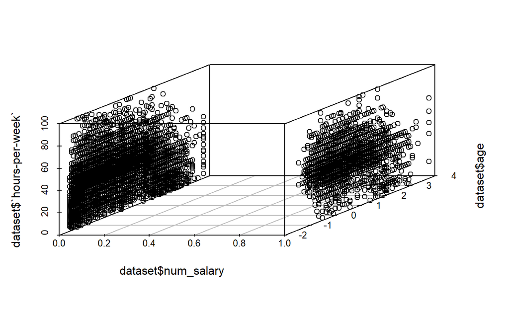

```r
scatterplot3d(dataset$num_salary,dataset$age, dataset$`hours-per-week`)
```

*Pie chart

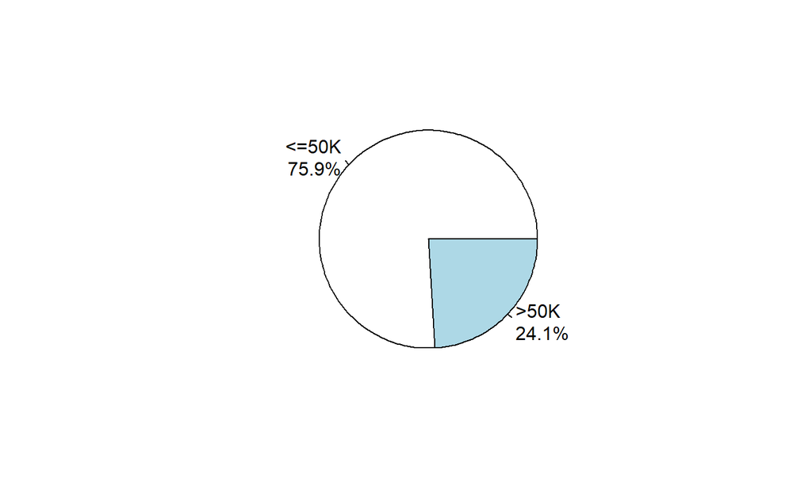

```r
tab <- dataset$salary %>% table()
precentages <- tab %>% prop.table() %>% round(3) * 100
txt <- paste0(names(tab), '\n', precentages, '%')
pie(tab, labels=txt)
```

##CLUSTERING

First, we install the needed packages and libraries.

```r
install.packages("dplyr")
```

```
Error in install.packages : Updating loaded packages
```

```r
install.packages("tidyverse")
install.packages("e1071")
install.packages("cluster")
install.packages("factoextra")
install.packages("fpc")
library(dplyr)
library(tidyverse)
library(e1071)
library(cluster)
library(factoextra)
library(fpc)
```

Take a sample of the first 10,000 rows in the dataset.

```r
sampleDataset = dataset[1:10000,]
```

Preparing the data before clustering:

We will first start by deleting the class label, as clustering is an unsupervised learning.

```r
data_clustring <- subset(sampleDataset, select = -salary)
data_clustring <- subset(data_clustring, select = -num_salary)
print(data_clustring)
```

| age | workclass | fnlwgt | education-num | marital-status | occupation | relationship | race | sex | hours-per-week | native-country |
| --- | --- | --- | --- | --- | --- | --- | --- | --- | --- | --- |
| 0.03162036 | 8 | -1.0643248559 | 13 | 5 | 2 | 8 | 5 | 2 | 40 | 40 |
| 0.83812705 | 7 | -1.0094204954 | 13 | 3 | 5 | 7 | 5 | 2 | 13 | 40 |
| -0.04169842 | 5 | 0.2443790801 | 9 | 1 | 7 | 5 | 5 | 2 | 40 | 40 |
| 1.05808342 | 5 | 0.4251039594 | 7 | 3 | 7 | 5 | 3 | 2 | 40 | 40 |
| -0.77488632 | 5 | 1.4074893479 | 13 | 3 | 11 | 5 | 3 | 1 | 40 | 6 |
| -0.11501721 | 5 | 0.8975088458 | 14 | 3 | 5 | 5 | 5 | 1 | 40 | 40 |
| 0.76480826 | 5 | -0.2810637027 | 5 | 4 | 9 | 5 | 3 | 1 | 16 | 24 |
| 0.98476463 | 7 | 0.1874945624 | 9 | 3 | 5 | 7 | 5 | 2 | 45 | 40 |
| -0.55492995 | 5 | -1.3649961033 | 14 | 5 | 11 | 5 | 5 | 1 | 50 | 40 |
| 0.25157673 | 5 | -0.2880558369 | 13 | 3 | 5 | 5 | 5 | 2 | 40 | 40 |

[output cut: 990 more lines]

```r
NA
```

scaling the data

```r
data_clustring <- scale(data_clustring)
```

#Data after preparing

```r
summary(data_clustring)
```

```
      age            workclass          fnlwgt        education-num
 Min.   :-1.5762   Min.   :-2.643   Min.   :-1.6124   Min.   :-3.56366
 1st Qu.:-0.7680   1st Qu.: 0.089   1st Qu.:-0.6787   1st Qu.:-0.42235
 Median :-0.1067   Median : 0.089   Median :-0.1084   Median :-0.02968
 Mean   : 0.0000   Mean   : 0.000   Mean   : 0.0000   Mean   : 0.00000
 3rd Qu.: 0.6280   3rd Qu.: 0.089   3rd Qu.: 0.4578   3rd Qu.: 0.75564
 Max.   : 3.7874   Max.   : 2.821   Max.   : 9.7413   Max.   : 2.32630
 marital-status      occupation       relationship         race
 Min.   :-1.7301   Min.   :-1.5493   Min.   :-2.643   Min.   :-4.3336
 1st Qu.:-0.4054   1st Qu.:-0.8467   1st Qu.: 0.089   1st Qu.: 0.3911
 Median :-0.4054   Median : 0.0901   Median : 0.089   Median : 0.3911
 Mean   : 0.0000   Mean   : 0.0000   Mean   : 0.000   Mean   : 0.0000
 3rd Qu.: 0.9193   3rd Qu.: 0.7927   3rd Qu.: 0.089   3rd Qu.: 0.3911
 Max.   : 2.2440   Max.   : 1.7295   Max.   : 2.821   Max.   : 0.3911
      sex          hours-per-week     native-country
 Min.   :-1.4232   Min.   :-3.27316   Min.   :-4.6029
 1st Qu.:-1.4232   1st Qu.:-0.03595   1st Qu.: 0.2959
 Median : 0.7026   Median :-0.03595   Median : 0.2959
 Mean   : 0.0000   Mean   : 0.00000   Mean   : 0.0000
 3rd Qu.: 0.7026   3rd Qu.: 0.37908   3rd Qu.: 0.2959
 Max.   : 0.7026   Max.   : 4.77836   Max.   : 0.5471
```

```r
str(data_clustring)
```

```
 num [1:10000, 1:11] 0.0402 0.8484 -0.0333 1.0689 -0.768 ...
 - attr(*, "dimnames")=List of 2
  ..$ : NULL
  ..$ : chr [1:11] "age" "workclass" "fnlwgt" "education-num" ...
 - attr(*, "scaled:center")= Named num [1:11] -0.00851 4.8697 0.00858 10.0756 3.6121 ...
  ..- attr(*, "names")= chr [1:11] "age" "workclass" "fnlwgt" "education-num" ...
 - attr(*, "scaled:scale")= Named num [1:11] 0.998 1.464 1.007 2.547 1.51 ...
  ..- attr(*, "names")= chr [1:11] "age" "workclass" "fnlwgt" "education-num" ...
```

It is a good idea to experiment with different values of k to determine the best value for our dataset. By using various methods, such as the silhouette coefficient or the gap statistic, to evaluate the quality of different clustering solutions and select the one that best represents the underlying structure of the data.

#Perform K-means clustering (for k = 2 clusters)

```r
kmeans_model <- kmeans(data_clustring,2 , nstart = 50)
kmeans_model
```

```
K-means clustering with 2 clusters of sizes 8497, 1503

Cluster means:
          age  workclass       fnlwgt education-num marital-status  occupation
1 -0.03320144  0.3421425  0.001798046   -0.01522100    -0.01348648  0.09519827
2  0.18769968 -1.9342550 -0.010165001    0.08604977     0.07624395 -0.53819006
  relationship        race         sex hours-per-week native-country
1    0.3421425  0.02117941  0.02983603     0.04296261    -0.01096553
2   -1.9342550 -0.11973480 -0.16867380    -0.24288311     0.06199209

Clustering vector:
   [1] 1 1 1 1 1 1 1 1 1 1 1 1 1 1 1 1 1 1 1 1 1 1 2 1 1 2 1 2 1 1 2 1 1 2 1 1 1 1
  [39] 1 1 1 1 1 1 1 2 1 1 1 1 1 1 1 2 1 1 1 1 1 1 1 2 1 1 1 1 1 1 1 2 1 1 1 1 1 1
  [77] 1 2 1 2 1 1 1 1 1 1 2 1 1 2 1 1 1 1 2 2 1 1 1 2 1 1 1 1 1 1 2 1 2 1 1 1 1 1
 [115] 1 1 1 2 1 1 1 1 1 1 1 1 1 1 2 1 1 1 1 1 1 2 1 1 1 1 1 1 1 1 1 1 1 1 1 2 2 1
```

[output cut: 33 more lines]

# Extract the cluster assignments

```r
clusters <- kmeans_model$cluster
```

# Visualize the clusters

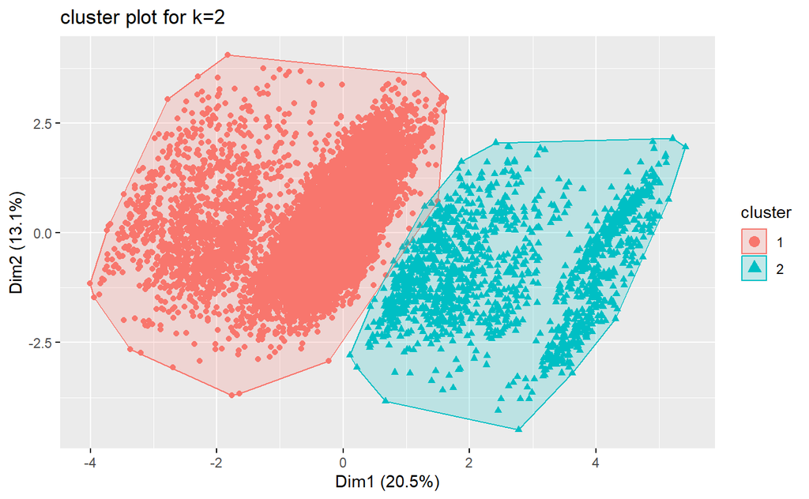

```r
fviz_cluster(list(data = data_clustring, cluster = clusters), geom = "point", main= "cluster plot for k=2")
```

# Calculating the avg silhouette

|  | cluster | size | ave.sil.width |
| --- | --- | --- | --- |
| 1 | 1 | 8497 | 0.24 |
| 2 | 2 | 1503 | 0.16 |

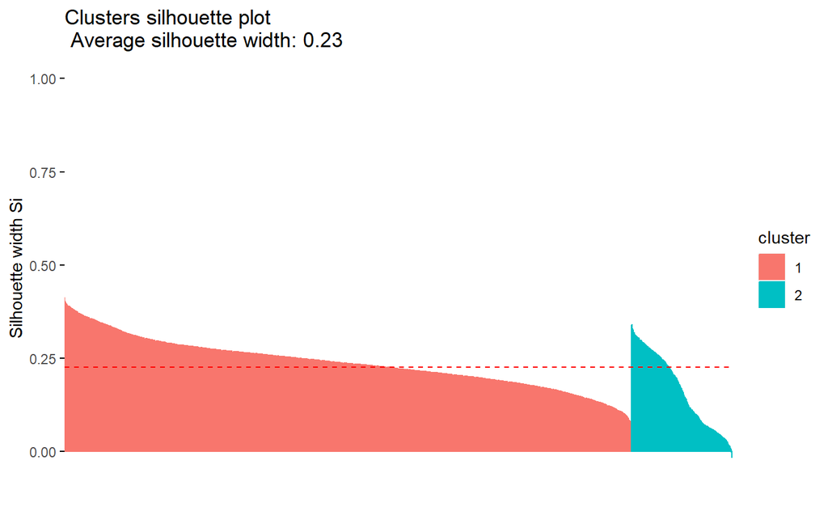

```r
avg_sil=silhouette (kmeans_model$cluster, dist(data_clustring))
fviz_silhouette(avg_sil)
```

The WCSS is a measure of the compactness of the clusters, and it represents the total distance of all data points within their respective clusters. A lower WCSS indicates that the clusters are more compact and well-separated, while a higher WCSS suggests that the clusters are more spread out and less distinct.

# Total within-cluster sum of square

```r
kmeans_model$tot.withinss
```

```
[1] 95968.12
```

# Calculate BCubed precision and recall

# First we set the ground truth

```r
ground_truth <- c(sampleDataset$salary)
```

# Setting the functions for calculating the BCubed precision and recall

```r
BCubed_Precision <- function(clusters, ground_truth) {
  n <- length(clusters)
  precision <- 0
  for (i in 1:n) {
    same_cluster <- clusters == clusters[i]
    same_ground_truth <- ground_truth == ground_truth[i]
    precision <- precision + sum(same_cluster & same_ground_truth) / sum(same_cluster)
  }
  precision <- precision / n
  return(precision)
}

BCubed_Recall <- function(clusters, ground_truth) {
  n <- length(clusters)
  recall <- 0
  for (i in 1:n) {
    same_cluster <- clusters == clusters[i]
    same_ground_truth <- ground_truth == ground_truth[i]
    recall <- recall + sum(same_cluster & same_ground_truth) / sum(same_ground_truth)
  }
  recall <- recall / n
  return(recall)
}
```

# Calculate BCubed precision and recall using the cluster assignments and ground truth

```r
precision <- BCubed_Precision(clusters, ground_truth)
recall <- BCubed_Recall(clusters, ground_truth)
```

# View the calculated precision and recall

```r
print(precision)
```

```
[1] 0.6377647
```

```r
print(recall)
```

```
[1] 0.7446205
```

# Perform K-means clustering (for k = 3 clusters)

```r
kmeans_model <- kmeans(data_clustring,3 , nstart = 50)
kmeans_model
```

```
K-means clustering with 3 clusters of sizes 3451, 5075, 1474

Cluster means:
         age  workclass      fnlwgt education-num marital-status  occupation
1 -0.6129047  0.2313130  0.11446488   -0.16667949     0.88088214  0.08385536
2  0.3581877  0.4082538 -0.07460318    0.08645017    -0.62246115  0.10832788
3  0.2017173 -1.9471840 -0.01113105    0.09258908     0.08077753 -0.56930043
  relationship       race        sex hours-per-week native-country
1    0.2313130 -0.1969351 -0.4277695     -0.3916147    -0.07658716
2    0.4082538  0.1692836  0.3415010      0.3397252     0.03372772
3   -1.9471840 -0.1217715 -0.1742775     -0.2528109     0.06318463

Clustering vector:
   [1] 2 2 2 2 1 2 1 2 1 2 2 2 1 1 2 1 1 1 2 2 2 1 3 2 2 3 1 3 2 2 3 1 2 3 1 1 1 1
  [39] 2 2 2 2 2 1 1 3 2 2 2 1 1 1 2 3 2 2 2 2 2 2 2 3 2 2 2 2 2 2 2 3 1 1 2 1 2 1
```

[output cut: 35 more lines]

# Extract the cluster assignments

```r
clusters <- kmeans_model$cluster
```

# Visualize the clusters

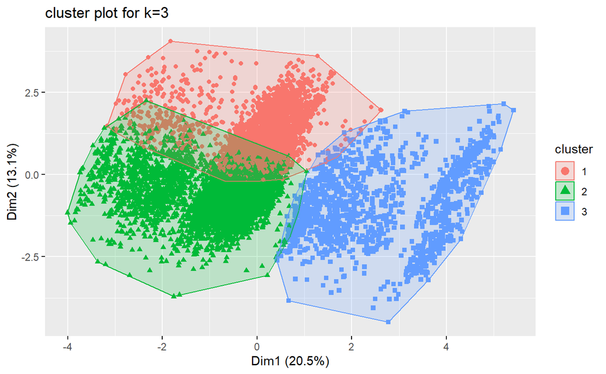

```r
fviz_cluster(list(data = data_clustring, cluster = clusters), geom = "point", main= "cluster plot for k=3")
```

# calculating the avg silhouette

|  | cluster | size | ave.sil.width |
| --- | --- | --- | --- |
| 1 | 1 | 3451 | 0.10 |
| 2 | 2 | 5075 | 0.16 |
| 3 | 3 | 1474 | 0.13 |

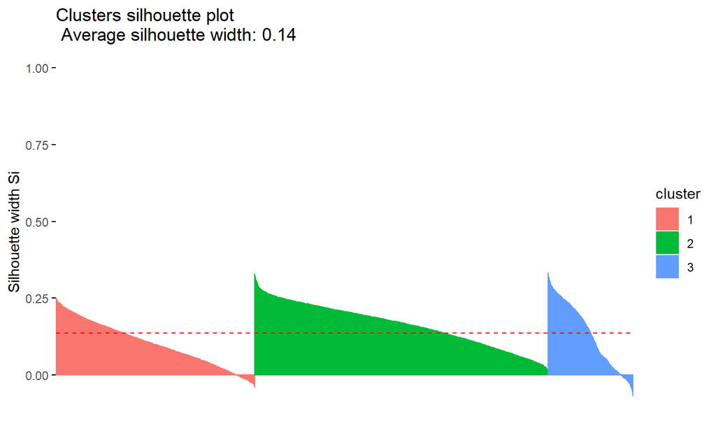

```r
avg_sil=silhouette (kmeans_model$cluster, dist(data_clustring))
fviz_silhouette(avg_sil)
```

# Total within-cluster sum of square

```r
kmeans_model$tot.withinss
```

```
[1] 86497.36
```

# Calculate BCubed precision and recall

# First we set the ground truth

```r
ground_truth <- c(sampleDataset$salary)
```

# Setting the functions for calculating the BCubed precision and recall

```r
BCubed_Precision <- function(clusters, ground_truth) {
  n <- length(clusters)
  precision <- 0
  for (i in 1:n) {
    same_cluster <- clusters == clusters[i]
    same_ground_truth <- ground_truth == ground_truth[i]
    precision <- precision + sum(same_cluster & same_ground_truth) / sum(same_cluster)
  }
  precision <- precision / n
  return(precision)
}

BCubed_Recall <- function(clusters, ground_truth) {
  n <- length(clusters)
  recall <- 0
  for (i in 1:n) {
    same_cluster <- clusters == clusters[i]
    same_ground_truth <- ground_truth == ground_truth[i]
    recall <- recall + sum(same_cluster & same_ground_truth) / sum(same_ground_truth)
  }
  recall <- recall / n
  return(recall)
}
```

# Calculate BCubed precision and recall using the cluster assignments and ground truth

```r
precision <- BCubed_Precision(clusters, ground_truth)
recall <- BCubed_Recall(clusters, ground_truth)
```

# View the calculated precision and recall

```r
print(precision)
```

```
[1] 0.6753733
```

```r
print(recall)
```

```
[1] 0.4412558
```

# Perform K-means clustering (for k = 4 clusters)

```r
kmeans_model <- kmeans(data_clustring,4 , nstart = 50)
kmeans_model
```

```
K-means clustering with 4 clusters of sizes 3219, 565, 4801, 1415

Cluster means:
         age  workclass      fnlwgt education-num marital-status  occupation
1 -0.6299837  0.2354160  0.08973503  -0.127637744     0.91124311  0.07569308
2  0.1064049  0.1010913  0.08681157   0.008538518     0.02246520  0.15186310
3  0.3480532  0.4048484 -0.06545115   0.059381605    -0.63857285  0.10170934
4  0.2097495 -1.9495393 -0.01673117   0.085477418     0.08466704 -0.57792594
  relationship       race         sex hours-per-week native-country
1    0.2354160 -0.1295997 -0.43064969    -0.39092062      0.2053058
2    0.1010913 -0.5099551  0.04790518     0.02090537     -3.7698787
3    0.4048484  0.1780292  0.33639158     0.33652846      0.2400029
4   -1.9495393 -0.1055917 -0.18079227    -0.26085599      0.2239210

Clustering vector:
```

[output cut: 37 more lines]

# Extract the cluster assignments

```r
clusters <- kmeans_model$cluster
```

# Visualize the clusters

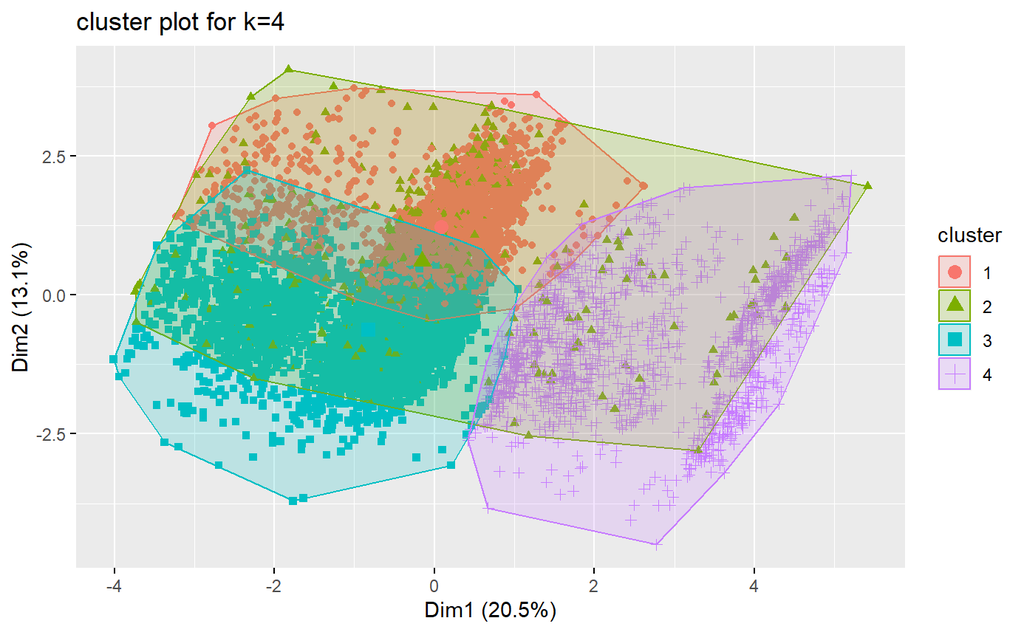

```r
fviz_cluster(list(data = data_clustring, cluster = clusters), geom = "point", main= "cluster plot for k=4")
```

# Calculating the avg silhouette

|  | cluster | size | ave.sil.width |
| --- | --- | --- | --- |
| 1 | 1 | 3219 | 0.12 |
| 2 | 2 | 565 | 0.18 |
| 3 | 3 | 4801 | 0.16 |
| 4 | 4 | 1415 | 0.13 |

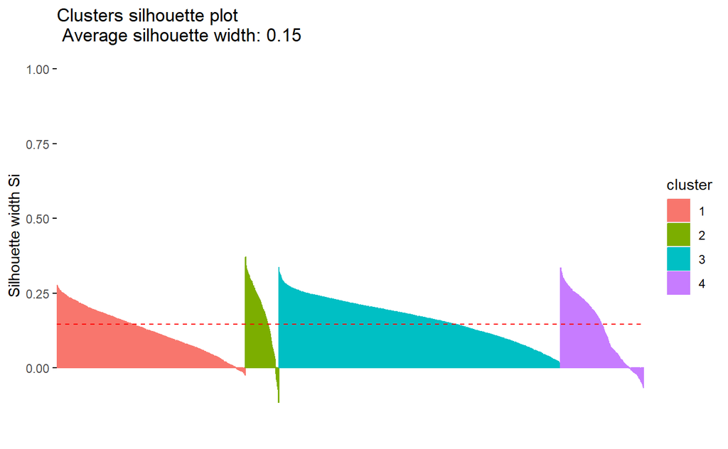

```r
avg_sil=silhouette (kmeans_model$cluster, dist(data_clustring))
fviz_silhouette(avg_sil)
```